# Inferential Statistics Course Project

Wally Thornton

August 22, 2015

This course project consists of two sections, one a simulation exercise and the second an inferential data analysis.

## Section 1: A Simulation Exercise

Using the simulation of an exponential distribution, we will explore the relationships between the sample and the theoretical population (including mean and variance), and demonstrate that the distribution of sample means adheres to a Gaussian (normal) distribution, even though the original distribution is exponential.

### Run the simulations

The first step is to set up the simulation environment and load packages that might be needed. (Code not shown. Throughout report only code directly generating results will be shown, to save space.)

We then create an exponential distribution simulation with a sample size of 40 (n=40) and a rate of 0.2 ($\lambda$=0.2). We’ll use the `rexp()` function in R, which randomly pull values from an exponential distribution with a mean of 1/$\lambda$, or 5, and repeat this 1,000 times (r=1000) to get a nice, big matrix.

```r
set.seed(42)
n <- 40
lambda <- 0.2
r <- 1000
my_samples <- matrix(rexp(n*r, lambda), r)
```

### Calculate and compare the sample mean to the theoretical mean

Now that we have our simulation results, we’ll calculate the mean for each 40-sample run and capture all 1,000.

```r
sample_means <- apply(my_samples, 1, mean)
```

How do they compare to our theoretical mean of 5? While the mean of each sample ranges from 3.14 to 7.88, the mean of the sample means is 4.99, **very close to our theoretical mean of 5**.

```
##    Min. 1st Qu.  Median    Mean 3rd Qu.    Max.
##   3.141   4.406   4.919   4.987   5.504   7.882
```

This is visually evident when we plot the distributions:

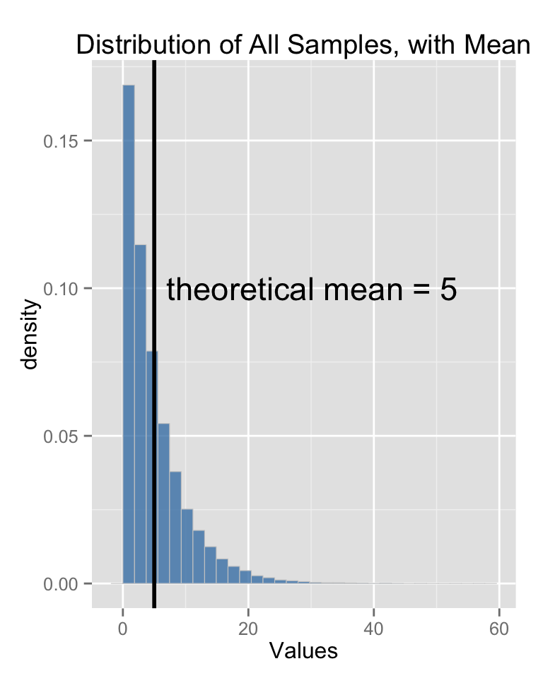

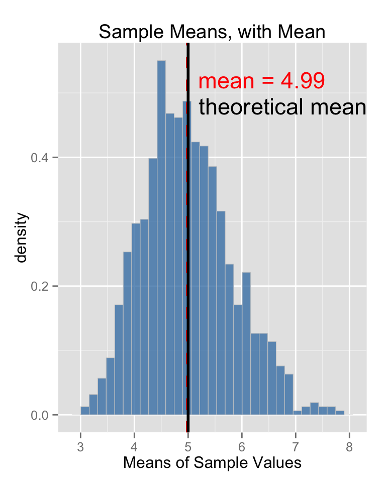

### Calculate and compare the sample variance to the theoretical variance

The variance of the sampling distribution of the mean (also known as the standard error of the mean) is defined as $\sigma_\mu^2 = \sigma^2/N$, that is, the population variance divided by the sample size. Plugging in our values results in a standard error of the mean of:

```r
se <- 1/lambda^2/n
paste("Standard error of the mean: ", se)
```

```
## [1] "Standard error of the mean:  0.625"
```

This is significantly less than the theoretical population variance. Why? This is because we are estimating how far the sample mean is likely to be from the population mean and as sample sizes get larger, the standard error will trend toward zero because the estimate improves.

```
## stat_bin: binwidth defaulted to range/30. Use 'binwidth = x' to adjust this.
```

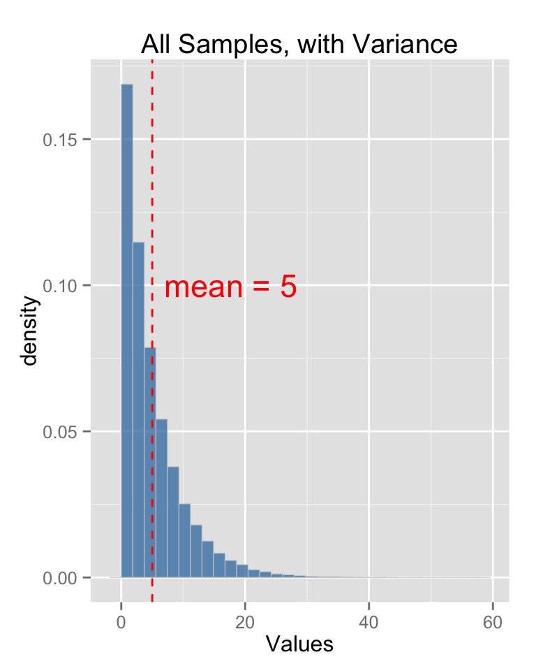

```
## stat_bin: binwidth defaulted to range/30. Use 'binwidth = x' to adjust this.
```

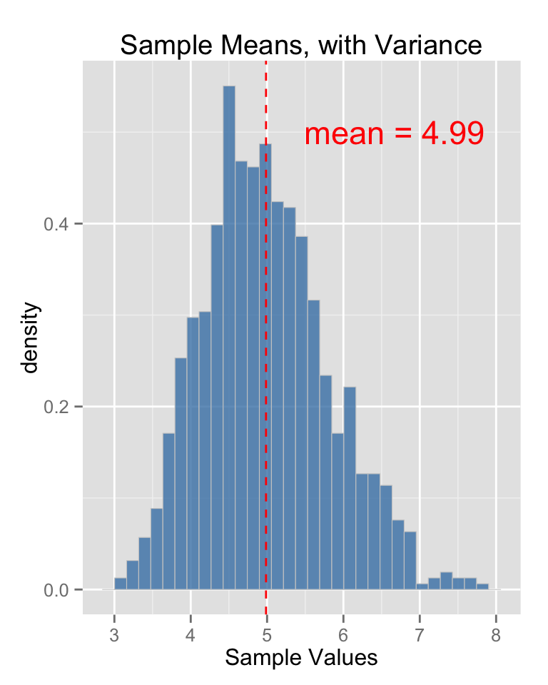

### Analyze the distribution of the sample mean

Looking at the histogram of the 40,000 randomly generated exponents, it’s obvious that the data are not normally distributed and actually follow an exponential distribution. If we plot the means of each 40-value observation, we find that they are not distributed exponentially, but rather follow a normal distribution. Here are the same plots as above, now with their respective density curves overlaid:

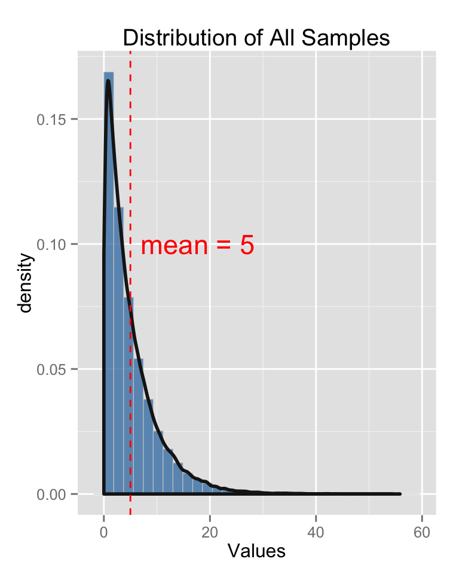

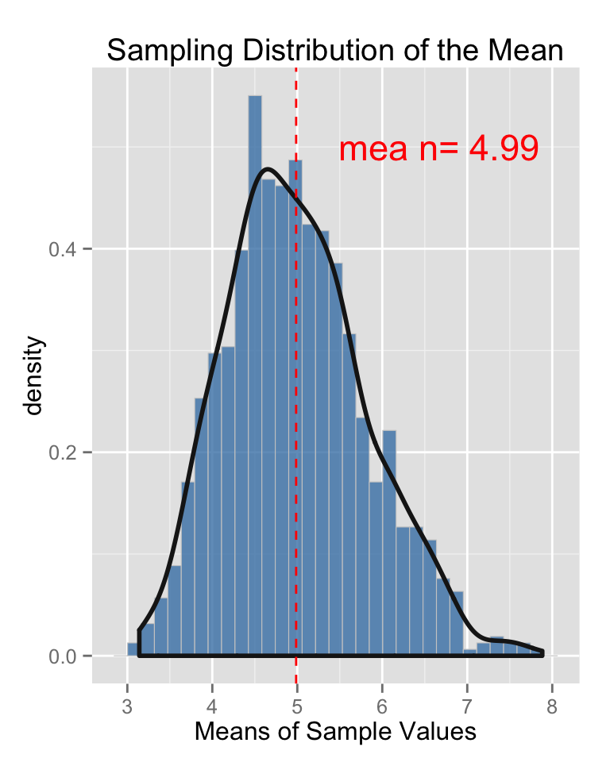

Visually, the distribution of the sample means is much closer to normal than the distribution of the sample itself. If the distribution is normal, we expect the mean of the distribution to be equal to the median and about 95% of the results within 1.96 standard deviations, which we find to be approximately the case:

```r
lower <- mean(sample_means) - 1.96*sd(sample_means)
upper <- mean(sample_means) + 1.96*sd(sample_means)
set_check <- sum(sample_means > lower & sample_means < upper)/length(sample_means)
```

```
## [1] "Mean:  4.99"
```

```
## [1] "Median:  4.92"
```

```
## [1] "Percentage of sampling means within 1.96 standard deviations:  95.4%"
```

To confirm these checks with something more concrete, we can run a quantile-quantile (Q-Q) plot. The Q-Q plot compares each point in the dataset to where they would be in a perfectly normal distribution with the same mean and standard deviation:

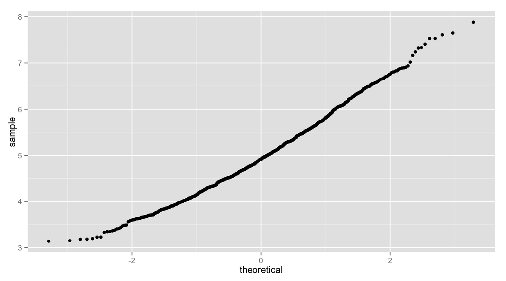

```r
qplot(sample = sample_means)
```

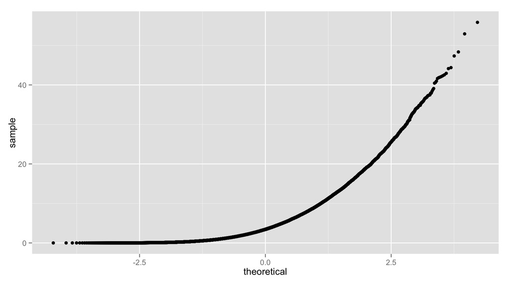

```r
qplot(sample = c(my_samples))
```

Given the linearity of the Q-Q plot and what we see with the standard deviations, we can feel comfortable that the sampling distribution of the means is indeed normally distributed.

## Section 2: Basic Inferential Data Analysis

Using the ToothGrowth data from the R datasets package, we will first perform some exploratory data analysis to get a feel for the data set and then provide a basic summary. We’ll then compare tooth growth by supp and dose, using confidence intervals and hypothesis testing. Based on this analysis, we’ll show that Vitamin C results in increased tooth growth, regardless of whether it comes from orange juice or ascorbic acid, at least to 2.0mg dosages.

### Exploratory Data Analysis

The first step is to load the packages we’ll need, along with the dataset, and get a sense of the structure of ToothGrowth. R’s documentation states that the ToothGrowth dataset is the effect of Vitamin C on tooth growth in guinea pigs. Ten guinea pigs were each given three dose levels of Vitamin C (0.5, 1 and 2 mg) with each of two delivery methods (orange juice and ascorbic acid), and their tooth growth measured after each test. Therefore, we’d expect to see 60 observations in the dataset.

```r
ensurePkg("dplyr")
data("ToothGrowth")
str(ToothGrowth)
```

```
## 'data.frame':    60 obs. of  3 variables:
##  $ len : num  4.2 11.5 7.3 5.8 6.4 10 11.2 11.2 5.2 7 ...
##  $ supp: Factor w/ 2 levels "OJ","VC": 2 2 2 2 2 2 2 2 2 2 ...
##  $ dose: num  0.5 0.5 0.5 0.5 0.5 0.5 0.5 0.5 0.5 0.5 ...
```

We see that there are 60 observations of three variables: * len, which is the length of observed tooth growth * supp, a variable with two values: “OJ” and “VC”, which is the supplement type * dose, which is the dose in milligrams of orange juice or vitamin C given to each subject

To get a sense of the range of values for `len`, we run a quick summary of the variable:

```r
summary(ToothGrowth$len)
```

```
##    Min. 1st Qu.  Median    Mean 3rd Qu.    Max.
##    4.20   13.08   19.25   18.81   25.28   33.90
```

Taking a look at a few of the rows, it appears that there might be some correlation between `dose` and `len`:

```r
head(ToothGrowth)
```

```
##    len supp dose
## 1  4.2   VC  0.5
## 2 11.5   VC  0.5
## 3  7.3   VC  0.5
## 4  5.8   VC  0.5
## 5  6.4   VC  0.5
## 6 10.0   VC  0.5
```

```r
tail(ToothGrowth)
```

```
##     len supp dose
## 55 24.8   OJ    2
## 56 30.9   OJ    2
## 57 26.4   OJ    2
## 58 27.3   OJ    2
## 59 29.4   OJ    2
## 60 23.0   OJ    2
```

Plotting the values for each combination of supplement and dose, it is at least visually suggestive that there is a correlation between greater doses of Vitamin C and tooth growth:

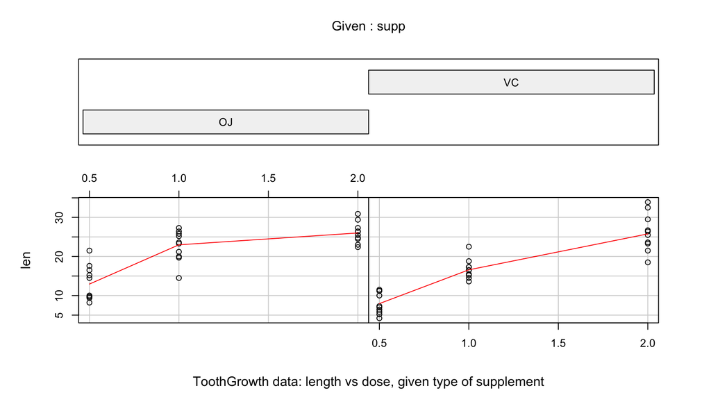

```r
coplot(len ~ dose | supp, data = ToothGrowth, panel = panel.smooth,
       xlab = "ToothGrowth data: length vs dose, given type of supplement")
```

The conditioning plot above shows each tooth growth length observation for each combination of dose, broken out by type of supplement. It illustrates the increase in growth length under higher Vitamin C doses for both supplements, with OJ appearing to do better at lower doses but VC closing the gap at 2.0mg with a similar mean (albeit greater variance).

To confirm the correlation we see in the conditioning plot, we’ll calculate the correlation between dose and tooth growth. Since there is a difference in results between OJ and VC, we first group by `supp` and `dose` and calculate the means.

```r
grouped_results <- ToothGrowth %>% group_by(supp, dose) %>% summarize(len.mean = mean(len))
print(grouped_results)
```

```
## Source: local data frame [6 x 3]
## Groups: supp
##
##   supp dose len.mean
## 1   OJ  0.5    13.23
## 2   OJ  1.0    22.70
## 3   OJ  2.0    26.06
## 4   VC  0.5     7.98
## 5   VC  1.0    16.77
## 6   VC  2.0    26.14
```

And then calculate the correlation between dose and mean length for each supplement:

```r
grouped_cor_OJ <- cor(grouped_results[grouped_results$supp == "OJ", ]$dose, grouped_results[grouped_results$supp == "OJ", ]$len.mean)
grouped_cor_VC <- cor(grouped_results[grouped_results$supp == "VC", ]$dose, grouped_results[grouped_results$supp == "VC", ]$len.mean)
```

The means of tooth growth are very highly correlated with Vitamin C supplements, regardless of the source of the C (correlation for OJ: 0.8967416; correlation for VC: 0.9852978. But how can we be sure that this is statistically valid? In the next section, we will answer this question.

We also want to see whether or not the data are normally distributed, since this will affect which test statistic to use in our analysis. Given that each combination of `supp` and `dose` is unique, we cannot look at the entire `len` column so we’ll break it down.

Let’s subset by 0.5mg and 2.0mg dosages for each supplement and then create a quantile-quantile (Q-Q) plot to test for normality. The Q-Q plot compares each point in the dataset to where they would be in a perfectly normal distribution with the same mean and standard deviation. In this case, we’ll plot the 2.0mg and 0.5mg doses for each supplement.

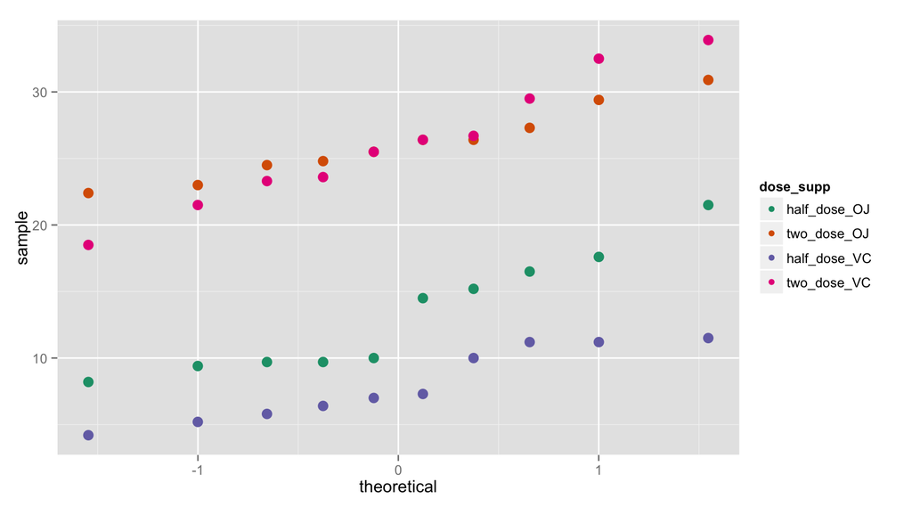

```r
half_dose_OJ <- ToothGrowth[ToothGrowth$dose == 0.5 & ToothGrowth$supp == "OJ", ]$len
two_dose_OJ <- ToothGrowth[ToothGrowth$dose == 2 & ToothGrowth$supp == "OJ", ]$len
half_dose_VC <- ToothGrowth[ToothGrowth$dose == 0.5 & ToothGrowth$supp == "VC", ]$len
two_dose_VC <- ToothGrowth[ToothGrowth$dose == 2 & ToothGrowth$supp == "VC", ]$len
qq_df <- data.frame(cbind(half_dose_OJ, two_dose_OJ, half_dose_VC, two_dose_VC))
qq_df <- gather(qq_df, "dose_supp", "len")

p <- qplot(sample=len, data=qq_df, color=dose_supp, size=4)
p + scale_color_brewer(palette="Dark2") + guides(size=FALSE)
```

```r
shapiro.test(half_dose_OJ)
```

```
##
##  Shapiro-Wilk normality test
##
## data:  half_dose_OJ
## W = 0.8927, p-value = 0.182
```

```r
shapiro.test(two_dose_OJ)
```

```
##
##  Shapiro-Wilk normality test
##
## data:  two_dose_OJ
## W = 0.9626, p-value = 0.8148
```

```r
shapiro.test(half_dose_VC)
```

```
##
##  Shapiro-Wilk normality test
##
## data:  half_dose_VC
## W = 0.89, p-value = 0.1696
```

```r
shapiro.test(two_dose_VC)
```

```
##
##  Shapiro-Wilk normality test
##
## data:  two_dose_VC
## W = 0.9733, p-value = 0.9194
```

We next look at the doses that were administered and confirm that they were given equally in the form of both orange juice and ascorbic acid. This gives us confidence that we do not have any missing observations.

```r
unique(ToothGrowth$dose)
```

```
## [1] 0.5 1.0 2.0
```

```r
with(ToothGrowth, table(supp, dose))
```

```
##     dose
## supp 0.5  1  2
##   OJ  10 10 10
##   VC  10 10 10
```

The final critical thing to notice about the dataset is that there is **no unique identifier for each guinea pig**. This means that although the same animals were used for each dose and supplement, we have no way to match them up and therefore no way to identify which results are paired.

### Comparison of Tooth Growth Results by ‘supp’ and ‘dose’

As discussed in the previous section, the means of tooth growth do increase in response to greater dosages of Vitamin C, regardless of the source of the C, but we want to confirm this statistically with a reasonable level of confidence.

Also discussed in the previous section, while the samples are paired, **we cannot identify which guinea pig is which so we cannot accurately pair them**. We therefore will not be able to use the paired t-test. If we had identifiers for which `len` result belonged to which guinea pig, we could have.

We could group both OJ and VC and compare tooth growth for the guinea pigs, but the means are quite different between the two supplements.

```r
print(grouped_results)
```

```
## Source: local data frame [6 x 3]
## Groups: supp
##
##   supp dose len.mean
## 1   OJ  0.5    13.23
## 2   OJ  1.0    22.70
## 3   OJ  2.0    26.06
## 4   VC  0.5     7.98
## 5   VC  1.0    16.77
## 6   VC  2.0    26.14
```

To remove this issue, we will treat the OJ and VC treatments as separate experiments on the same subjects and analyze them separately. We will obtain the t statistic, confidence intervals and confidence intervals first formulaically for the OJ supplement and then directly using the R function `t.test()` for the VC.

If Vitamin C does increase tooth growth, we would expect greater dosages to yield greater growth (presumably up to some limit, but testing that limit is beyond the data provided). Therefore, for one or both supplements, mean tooth growth from dosages of 2.0mg should be greater than mean tooth growth from 0.5mg dosages. But if Vitamin C supplements do not result in increased tooth growth, the means should not differ significantly.

Our null hypothesis is therefore: $H_0: \mu_2 = \mu_{0.5}\quad \textrm{or, equivalently,} \quad H_0: \mu_2 - \mu_{0.5} = 0$

If Vitamin C does enhance tooth growth, we would expect to see increased growth under the 2.0mg dose, so our alternative hypothesis is: $H_a: \mu_2 > \mu_{0.5}\quad \textrm{or, equivalently,} \quad H_a: \mu_2 - \mu_{0.5} > 0$

```r
f_test_p <-var.test(half_dose_OJ, two_dose_OJ)
```

The resulting P-Value of 0.14 means that we can move forward with the two-sample t-test with equal variances.

The formulas we’re using to calculate the test statistic are: $t=\frac{\bar X_2 - \bar X_{0.5}}{s_p \sqrt{\frac{1}{n_2} + \frac{1}{n_{0.5}}} }$ $s_p=\sqrt\frac{(n_2 - 1)s_2^2 + (n_{0.5} - 1)s_{0.5}^2}{n_2 + n_{0.5} - 2}$

```r
n <- 20
x_two <- mean(two_dose_OJ)
x_half <- mean(half_dose_OJ)
s_two <- sd(two_dose_OJ)
s_half <- sd(half_dose_OJ)

sp <- sqrt( ((n-1)*s_two^2 + (n-1)*s_half^2)/(2*n-2) )
t <- (x_two-x_half)/(sp*sqrt(1/n + 1/n))
```

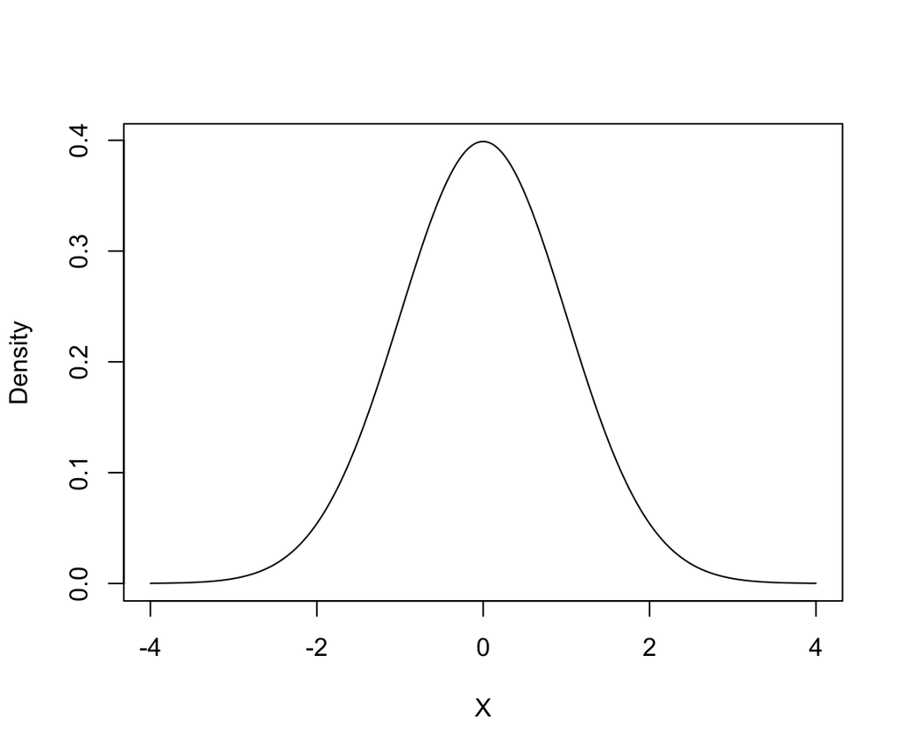

```r
t_test_OJ <- t.test(two_dose_OJ, half_dose_OJ, alternative = "greater", var.equal = TRUE)
t_test_OJ
```

```
##
##  Two Sample t-test
##
## data:  two_dose_OJ and half_dose_OJ
## t = 7.817, df = 18, p-value = 0.0000001701
## alternative hypothesis: true difference in means is greater than 0
## 95 percent confidence interval:
##  9.983898      Inf
## sample estimates:
## mean of x mean of y
##     26.06     13.23
```

Our P-Value of 0.0000002 < $\alpha$, so we reject the null hypothesis, in favor of the alternative hypothesis: there is evidence to suggest that Vitamin C when given by orange juice results in increased tooth growth.

To double-check our work, we look at the confidence intervals, using the formula: $\bar X_2 - \bar X_{0.5}\pm t_{df} s_p \sqrt{\frac{1}{n_2}+\frac{1}{n_{0.5}}}$

But we can pull the 95% confidence interval from the `t.test()` results:

```r
t_test_OJ_CI <- t.test(two_dose_OJ, half_dose_OJ, var.equal = TRUE)
```

Which results in a lower bound of 9.38 and an upper bound 16.28, which comfortably include the difference between our two sample means of 12.83, so the difference in our sample means is solidly within the range of our 95% confidence interval. Further, the entire interval is well above zero, which, under $H_a$, means that the difference between our two sample means is positive and therefore the means are not equivalent.

Now we will run the same tests for the ascorbic acid supplement, but using R functions directly.

```r
t_test_VC <- t.test(two_dose_VC, half_dose_VC, alternative = "greater", var.equal = TRUE)
t_test_VC
```

```
##
##  Two Sample t-test
##
## data:  two_dose_VC and half_dose_VC
## t = 10.3878, df = 18, p-value = 0.000000002479
## alternative hypothesis: true difference in means is greater than 0
## 95 percent confidence interval:
##  15.1285     Inf
## sample estimates:
## mean of x mean of y
##     26.14      7.98
```

```r
t_test_VC_CI <- t.test(two_dose_VC, half_dose_VC, var.equal = TRUE)
```

Calculating the 95% confidence intervals for the VC supp yields [14.49, 21.83], which again comfortably includes our mean and is well above zero.

### Conclusion

Given the limitations of the data, we had to make a number of assumptions:

- From the description of the dataset, the 10 guinea pigs comprised the entire study, so while this is not technically a random sample, it is obviously a valid representation of the population
- The observations are independent, particularly that the supplement and/or dosage used in previous trials didn’t affect the tooth growth in subsequent trials
- The data are normally distributed
- Since we could not identify which `len` result belonged to which subject, we had to treat the data as not paired
- The variances are approximately equal, which we checked with an F test

Even with these assumptions, the results show with high levels of confidence that Vitamin C in the form of orange juice and ascorbic acid does promote tooth growth.